# text_example_q2

Kristof Menyhert

02.06.2018

## Example of DeepLearning in R: Classifying movie reviews: a binary classification example

In this example I am training a deep learning model using R, Keras and TensorFlow for classifying IMDB movies based on reviews. Reviews will end up in two categories:

- 1 for positive
- 0 for negative

Setting up the environment:

```r
library(keras)
imdb <- dataset_imdb(num_words = 10000) #keep only the 10000 most frequent worsd
train_data <- imdb$train$x
train_labels <- imdb$train$y
test_data <- imdb$test$x
test_labels <- imdb$test$y
```

Lets inspect our train variable:

```r
str(train_data[[1]])
```

```
##  int [1:218] 1 14 22 16 43 530 973 1622 1385 65 ...
```

- Every number represent a different word

Lets also inspect our train target variable

```r
train_labels[[1]]
```

```
## [1] 1
```

There is 10000 different words as we set `num_words = 10000` at the beginning of our exercise

```r
max(sapply(train_data, max))
```

```
## [1] 9999
```

Can we code back our data to actual text? - Yes we can. See the code for it below:

```r
# Named list mapping words to an integer index.
word_index <- dataset_imdb_word_index()
reverse_word_index <- names(word_index)
names(reverse_word_index) <- word_index

# Decodes the review. Note that the indices are offset by 3 because 0, 1, and
# 2 are reserved indices for "padding," "start of sequence," and "unknown."
decoded_review <- sapply(train_data[[1]], function(index) {
  word <- if (index >= 3) reverse_word_index[[as.character(index - 3)]]
  if (!is.null(word)) word else "?"
})
cat(decoded_review)
```

```
## ? this film was just brilliant casting location scenery story direction everyone's really suited the part they played and you could just imagine being there robert ? is an amazing actor and now the same being director ? father came from the same scottish island as myself so i loved the fact there…
```

### Preparing the data:

One hot encoding for Xs.

```r
vectorize_sequences <- function(sequences, dimension = 10000) {
  # Creates an all-zero matrix of shape (length(sequences), dimension)
  results <- matrix(0, nrow = length(sequences), ncol = dimension)
  for (i in 1:length(sequences))
    # Sets specific indices of results[i] to 1s
    results[i, sequences[[i]]] <- 1
  results
}

x_train <- vectorize_sequences(train_data)
x_test <- vectorize_sequences(test_data)
```

See the actual results:

```r
str(x_train[1,])
```

```
##  num [1:10000] 1 1 0 1 1 1 1 1 1 0 ...
```

Convert the labels to numeric:

```r
y_train <- as.numeric(train_labels)
y_test <- as.numeric(test_labels)
```

### Building the model:

```r
model <- keras_model_sequential() %>%
  layer_dense(units = 16, activation = "relu", input_shape = c(10000)) %>%
  layer_dense(units = 16, activation = "relu") %>%
  layer_dropout(rate = 0.2) %>%
  layer_dense(units = 8, activation = "relu") %>%
  layer_dense(units = 1, activation = "sigmoid")
```

Setting up intimation measures:

```r
model %>% compile(
  optimizer = "adam",
  loss = "binary_crossentropy",
  metrics = c("accuracy")
)
```

How our model actually looks like:

```r
summary(model)
```

```
## ___________________________________________________________________________
## Layer (type)                     Output Shape                  Param #
## ===========================================================================
## dense_1 (Dense)                  (None, 16)                    160016
## ___________________________________________________________________________
## dense_2 (Dense)                  (None, 16)                    272
## ___________________________________________________________________________
## dropout_1 (Dropout)              (None, 16)                    0
## ___________________________________________________________________________
## dense_3 (Dense)                  (None, 8)                     136
## ___________________________________________________________________________
## dense_4 (Dense)                  (None, 1)                     9
## ===========================================================================
## Total params: 160,433
## Trainable params: 160,433
## Non-trainable params: 0
## ___________________________________________________________________________
```

As we can see we have: * 5 layers * 160,433 params (weights) which we have to optimize

Get a subset of the data:

```r
val_indices <- 1:10000

x_val <- x_train[val_indices,]
partial_x_train <- x_train[-val_indices,]

y_val <- y_train[val_indices]
partial_y_train <- y_train[-val_indices]
```

Run a model to see when we have to stop in order not to over-fit:

```r
history <- model %>% fit(
  partial_x_train,
  partial_y_train,
  epochs = 10,
  batch_size = 64,
  validation_split = 0.25
)
```

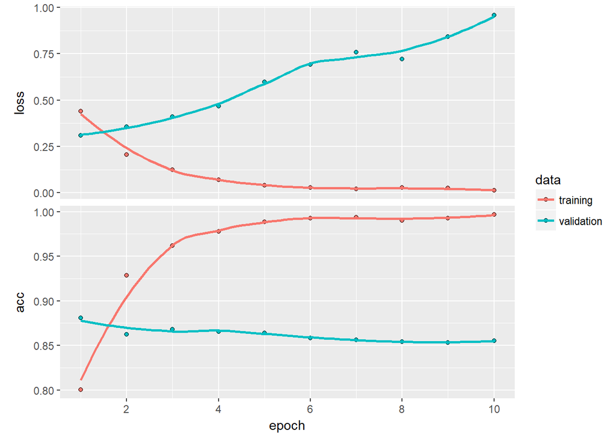

```r
plot(history)
```

```r
model <- keras_model_sequential() %>%
  layer_dense(units = 16, activation = "relu", input_shape = c(10000)) %>%
  layer_dense(units = 16, activation = "relu") %>%
  layer_dropout(rate = 0.2) %>%
  layer_dense(units = 8, activation = "relu") %>%
  layer_dense(units = 1, activation = "sigmoid")

model %>% compile(
  optimizer = "adam",
  loss = "binary_crossentropy",
  metrics = c("accuracy")
)

model %>% fit(x_train, y_train, epochs = 3, batch_size = 64)
results <- model %>% evaluate(x_test, y_test)
```

## Results:

```r
results
```

```
## $loss
## [1] 0.3708249
##
## $acc
## [1] 0.86872
```

The basic model gave us around 87% of accuracy. Which is a significantly better result then a random guess.